# PART A (15 Marks)

People Planed to Purchase & Actually Purchase are 400 Total is 2000

```python
probability = 400/2000
print("Joint Probability is: ",probability)
```

```
Joint Probability is:  0.2
```

A will be 400 & B will be 500

```python
total_Prob = 0.8
print(total_Prob)
```

```
0.8
```

## 2. An electrical manufacturing company conducts quality checks at specified periods on the products it manufactures. Historically, the failure rate for the manufactured item is 5%. Suppose a random sample of 10 manufactured items is selected. Answer the following questions. [4 Marks]

```python
import pandas as pd
import numpy as np
import seaborn as sns
import scipy.stats as stats
import matplotlib.pyplot as plt
%matplotlib inline
```

### 2.A. Probability that none of the items are defective? [1 Mark]

```python
#stats.binom.pmf(x,n,p)
probForNone = stats.binom.pmf(0,10,0.05)
print(probForNone)
```

```
0.5987369392383789
```

### 2.B. Probability that exactly one of the items is defective? [1 Mark]

```python
probForOne = stats.binom.pmf(1,10,0.05)
print(probForOne)
```

```
0.31512470486230504
```

### 2.C. Probability that two or fewer of the items are defective? [1 Mark]

```python
probForTwo = stats.binom.pmf(2,10,0.05)
print(probForTwo)
probFor2OrLess = probForNone + probForOne + probForTwo
print("Probability that 2 or less Item will be defective: ",probFor2OrLess)
```

```
0.07463479852001954
Probability that 2 or less Item will be defective:  0.9884964426207035
```

### 2.D. Probability that three or more of the items are defective ? [1 Mark]

```python
prob3OrMore = 1-probFor2OrLess
print(prob3OrMore)
```

```
0.011503557379296536
```

## 3

```python
# 3.A
sellSome = 1-stats.poisson.pmf(3,0)
print(sellSome)
```

```
1.0
```

```python
# 3.B
sellGre2Les5 = stats.poisson.pmf(3,2)+stats.poisson.pmf(3,3)+stats.poisson.pmf(3,4)
print(sellGre2Les5)
```

```
0.5998556667840358
```

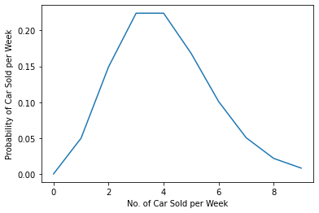

```python
# 3.C
lam = 3
x = np.arange(0,10,1)
y = stats.poisson.pmf(x,lam,loc=1)
plt.plot(x,y)
plt.xlabel("No. of Car Sold per Week")
plt.ylabel("Probability of Car Sold per Week")
plt.show()
```

## 4

```python
# 4A
probAllOCor = stats.binom.pmf(3,3,0.868)
print(probAllOCor)
```

```
0.653972032
```

```python
# 4B
probNoneOCor = stats.binom.pmf(0,3,0.868)
print(probNoneOCor)
```

```
0.002299968
```

```python
# 4C
probTwoOCor = stats.binom.pmf(2,3,0.868)
print(probTwoOCor)
```

```
0.29835590399999995
```

## 5

Suppose we want to invest in stock.

For investment we'll check which stock should had good perfomance in last some days.

We'll analyse perfomance stock and check in which stock should we invest so we can get higher return.

Based on that we'll have to invest.

# PART B (30 Marks)

## 1 Read the data set, clean the data and prepare final dataset to be used for analysis.

```python
basketBall = pd.read_csv('Basketball.csv')
basketBall.head()
```

|  | Team | Tournament | Score | PlayedGames | WonGames | DrawnGames | LostGames | BasketScored | BasketGiven | TournamentChampion | Runner-up | TeamLaunch | HighestPositionHeld |
| --- | --- | --- | --- | --- | --- | --- | --- | --- | --- | --- | --- | --- | --- |
| 0 | Team 1 | 86 | 4385 | 2762 | 1647 | 552 | 563 | 5947 | 3140 | 33 | 23 | 1929 | 1 |
| 1 | Team 2 | 86 | 4262 | 2762 | 1581 | 573 | 608 | 5900 | 3114 | 25 | 25 | 1929 | 1 |
| 2 | Team 3 | 80 | 3442 | 2614 | 1241 | 598 | 775 | 4534 | 3309 | 10 | 8 | 1929 | 1 |
| 3 | Team 4 | 82 | 3386 | 2664 | 1187 | 616 | 861 | 4398 | 3469 | 6 | 6 | 1931to32 | 1 |
| 4 | Team 5 | 86 | 3368 | 2762 | 1209 | 633 | 920 | 4631 | 3700 | 8 | 7 | 1929 | 1 |

```python
basketBall.tail()
```

|  | Team | Tournament | Score | PlayedGames | WonGames | DrawnGames | LostGames | BasketScored | BasketGiven | TournamentChampion | Runner-up | TeamLaunch | HighestPositionHeld |
| --- | --- | --- | --- | --- | --- | --- | --- | --- | --- | --- | --- | --- | --- |
| 56 | Team 57 | 1 | 34 | 38 | 8 | 10 | 20 | 38 | 66 | - | - | 2009-10 | 20 |
| 57 | Team 58 | 1 | 22 | 30 | 7 | 8 | 15 | 37 | 57 | - | - | 1956-57 | 16 |
| 58 | Team 59 | 1 | 19 | 30 | 7 | 5 | 18 | 51 | 85 | - | - | 1951~52 | 16 |
| 59 | Team 60 | 1 | 14 | 30 | 5 | 4 | 21 | 34 | 65 | - | - | 1955-56 | 15 |
| 60 | Team 61 | 1 | - | - | - | - | - | - | - | - | - | 2017~18 | 9 |

```python
basketBall.info()
```

```
<class 'pandas.core.frame.DataFrame'>
RangeIndex: 61 entries, 0 to 60
Data columns (total 13 columns):
 #   Column               Non-Null Count  Dtype
---  ------               --------------  -----
 0   Team                 61 non-null     object
 1   Tournament           61 non-null     int64
 2   Score                61 non-null     object
 3   PlayedGames          61 non-null     object
 4   WonGames             61 non-null     object
 5   DrawnGames           61 non-null     object
 6   LostGames            61 non-null     object
 7   BasketScored         61 non-null     object
 8   BasketGiven          61 non-null     object
 9   TournamentChampion   61 non-null     object
 10  Runner-up            61 non-null     object
 11  TeamLaunch           61 non-null     object
 12  HighestPositionHeld  61 non-null     int64
dtypes: int64(2), object(11)
memory usage: 6.3+ KB
```

```python
basketBall.isnull().sum()
```

```
Team                   0
Tournament             0
Score                  0
PlayedGames            0
WonGames               0
DrawnGames             0
LostGames              0
BasketScored           0
BasketGiven            0
TournamentChampion     0
Runner-up              0
TeamLaunch             0
HighestPositionHeld    0
dtype: int64
```

```python
basketBall.replace(to_replace='-',value='0',inplace=True)
basketBall['TeamLaunch']=basketBall['TeamLaunch'].str.slice(0,4)
basketBall.tail()
```

|  | Team | Tournament | Score | PlayedGames | WonGames | DrawnGames | LostGames | BasketScored | BasketGiven | TournamentChampion | Runner-up | TeamLaunch | HighestPositionHeld |
| --- | --- | --- | --- | --- | --- | --- | --- | --- | --- | --- | --- | --- | --- |
| 56 | Team 57 | 1 | 34 | 38 | 8 | 10 | 20 | 38 | 66 | 0 | 0 | 2009 | 20 |
| 57 | Team 58 | 1 | 22 | 30 | 7 | 8 | 15 | 37 | 57 | 0 | 0 | 1956 | 16 |
| 58 | Team 59 | 1 | 19 | 30 | 7 | 5 | 18 | 51 | 85 | 0 | 0 | 1951 | 16 |
| 59 | Team 60 | 1 | 14 | 30 | 5 | 4 | 21 | 34 | 65 | 0 | 0 | 1955 | 15 |
| 60 | Team 61 | 1 | 0 | 0 | 0 | 0 | 0 | 0 | 0 | 0 | 0 | 2017 | 9 |

```python
basketBall.describe(include='all')
```

|  | Team | Tournament | Score | PlayedGames | WonGames | DrawnGames | LostGames | BasketScored | BasketGiven | TournamentChampion | Runner-up | TeamLaunch | HighestPositionHeld |
| --- | --- | --- | --- | --- | --- | --- | --- | --- | --- | --- | --- | --- | --- |
| count | 61 | 61.000000 | 61 | 61 | 61 | 61 | 61 | 61 | 61 | 61 | 61 | 61 | 61.000000 |
| unique | 61 | NaN | 61 | 53 | 59 | 57 | 56 | 60 | 61 | 8 | 10 | 45 | NaN |
| top | Team 18 | NaN | 1020 | 30 | 8 | 44 | 37 | 70 | 633 | 0 | 0 | 1929 | NaN |
| freq | 1 | NaN | 1 | 3 | 2 | 2 | 3 | 2 | 1 | 52 | 48 | 10 | NaN |
| mean | NaN | 24.000000 | NaN | NaN | NaN | NaN | NaN | NaN | NaN | NaN | NaN | NaN | 7.081967 |
| std | NaN | 26.827225 | NaN | NaN | NaN | NaN | NaN | NaN | NaN | NaN | NaN | NaN | 5.276663 |
| min | NaN | 1.000000 | NaN | NaN | NaN | NaN | NaN | NaN | NaN | NaN | NaN | NaN | 1.000000 |
| 25% | NaN | 4.000000 | NaN | NaN | NaN | NaN | NaN | NaN | NaN | NaN | NaN | NaN | 3.000000 |
| 50% | NaN | 12.000000 | NaN | NaN | NaN | NaN | NaN | NaN | NaN | NaN | NaN | NaN | 6.000000 |
| 75% | NaN | 38.000000 | NaN | NaN | NaN | NaN | NaN | NaN | NaN | NaN | NaN | NaN | 10.000000 |
| max | NaN | 86.000000 | NaN | NaN | NaN | NaN | NaN | NaN | NaN | NaN | NaN | NaN | 20.000000 |

```python
convertTypes = ['Score', 'PlayedGames', 'WonGames', 'DrawnGames', 'LostGames', 'BasketScored', 'BasketGiven', 'TournamentChampion', 'Runner-up', 'TeamLaunch', 'HighestPositionHeld']
```

```python
bBall = basketBall.copy(deep=True)
bBall[convertTypes] = bBall[convertTypes].apply(pd.to_numeric, errors='coerce')
bBall.drop(60,inplace=True)
bBall.head()
```

|  | Team | Tournament | Score | PlayedGames | WonGames | DrawnGames | LostGames | BasketScored | BasketGiven | TournamentChampion | Runner-up | TeamLaunch | HighestPositionHeld |
| --- | --- | --- | --- | --- | --- | --- | --- | --- | --- | --- | --- | --- | --- |
| 0 | Team 1 | 86 | 4385 | 2762 | 1647 | 552 | 563 | 5947 | 3140 | 33 | 23 | 1929 | 1 |
| 1 | Team 2 | 86 | 4262 | 2762 | 1581 | 573 | 608 | 5900 | 3114 | 25 | 25 | 1929 | 1 |
| 2 | Team 3 | 80 | 3442 | 2614 | 1241 | 598 | 775 | 4534 | 3309 | 10 | 8 | 1929 | 1 |
| 3 | Team 4 | 82 | 3386 | 2664 | 1187 | 616 | 861 | 4398 | 3469 | 6 | 6 | 1931 | 1 |
| 4 | Team 5 | 86 | 3368 | 2762 | 1209 | 633 | 920 | 4631 | 3700 | 8 | 7 | 1929 | 1 |

```python
bBall.tail()
```

|  | Team | Tournament | Score | PlayedGames | WonGames | DrawnGames | LostGames | BasketScored | BasketGiven | TournamentChampion | Runner-up | TeamLaunch | HighestPositionHeld |
| --- | --- | --- | --- | --- | --- | --- | --- | --- | --- | --- | --- | --- | --- |
| 55 | Team 56 | 1 | 35 | 38 | 8 | 11 | 19 | 36 | 55 | 0 | 0 | 2016 | 17 |
| 56 | Team 57 | 1 | 34 | 38 | 8 | 10 | 20 | 38 | 66 | 0 | 0 | 2009 | 20 |
| 57 | Team 58 | 1 | 22 | 30 | 7 | 8 | 15 | 37 | 57 | 0 | 0 | 1956 | 16 |
| 58 | Team 59 | 1 | 19 | 30 | 7 | 5 | 18 | 51 | 85 | 0 | 0 | 1951 | 16 |
| 59 | Team 60 | 1 | 14 | 30 | 5 | 4 | 21 | 34 | 65 | 0 | 0 | 1955 | 15 |

```python
bBall.dtypes
```

```
Team                   object
Tournament              int64
Score                   int64
PlayedGames             int64
WonGames                int64
DrawnGames              int64
LostGames               int64
BasketScored            int64
BasketGiven             int64
TournamentChampion      int64
Runner-up               int64
TeamLaunch              int64
HighestPositionHeld     int64
dtype: object
```

```python
bBall.describe(include='all')
```

|  | Team | Tournament | Score | PlayedGames | WonGames | DrawnGames | LostGames | BasketScored | BasketGiven | TournamentChampion | Runner-up | TeamLaunch | HighestPositionHeld |
| --- | --- | --- | --- | --- | --- | --- | --- | --- | --- | --- | --- | --- | --- |
| count | 60 | 60.000000 | 60.000000 | 60.000000 | 60.000000 | 60.000000 | 60.000000 | 60.000000 | 60.000000 | 60.00000 | 60.000000 | 60.000000 | 60.000000 |
| unique | 60 | NaN | NaN | NaN | NaN | NaN | NaN | NaN | NaN | NaN | NaN | NaN | NaN |
| top | Team 18 | NaN | NaN | NaN | NaN | NaN | NaN | NaN | NaN | NaN | NaN | NaN | NaN |
| freq | 1 | NaN | NaN | NaN | NaN | NaN | NaN | NaN | NaN | NaN | NaN | NaN | NaN |
| mean | NaN | 24.383333 | 916.450000 | 810.100000 | 309.033333 | 192.083333 | 308.816667 | 1159.350000 | 1159.233333 | 1.45000 | 1.433333 | 1957.950000 | 7.050000 |
| std | NaN | 26.884620 | 1138.342899 | 877.465393 | 408.481395 | 201.985508 | 294.508639 | 1512.063948 | 1163.946914 | 5.51554 | 4.574679 | 26.646732 | 5.315232 |
| min | NaN | 1.000000 | 14.000000 | 30.000000 | 5.000000 | 4.000000 | 15.000000 | 34.000000 | 55.000000 | 0.00000 | 0.000000 | 1929.000000 | 1.000000 |
| 25% | NaN | 4.000000 | 104.250000 | 115.500000 | 34.750000 | 26.250000 | 62.750000 | 154.500000 | 236.000000 | 0.00000 | 0.000000 | 1934.750000 | 3.000000 |
| 50% | NaN | 12.000000 | 395.500000 | 424.500000 | 124.000000 | 98.500000 | 197.500000 | 444.000000 | 632.500000 | 0.00000 | 0.000000 | 1950.500000 | 6.000000 |
| 75% | NaN | 39.000000 | 1360.500000 | 1345.500000 | 432.750000 | 331.500000 | 563.500000 | 1669.750000 | 2001.250000 | 0.00000 | 0.000000 | 1977.250000 | 10.000000 |
| max | NaN | 86.000000 | 4385.000000 | 2762.000000 | 1647.000000 | 633.000000 | 1070.000000 | 5947.000000 | 3889.000000 | 33.00000 | 25.000000 | 2016.000000 | 20.000000 |

```python
# Five Number Summery
bMin = bBall.min()
Q1 = bBall.quantile(0.25)
Q2 = bBall.quantile(0.50)
Q3 = bBall.quantile(0.75)
bMax = bBall.max()
IQR = Q3-Q1
print("Min=\n",bMin,"\n\nQ1=\n",Q1,"\n\nQ2=\n",Q2,"\n\nQ3=\n",Q3,"\n\nMax=\n",bMax,"\n\nIQR=\n",IQR)
```

```
Min=
 Team                   Team 1
Tournament                  1
Score                      14
PlayedGames                30
WonGames                    5
DrawnGames                  4
LostGames                  15
BasketScored               34
BasketGiven                55
TournamentChampion          0
Runner-up                   0
TeamLaunch               1929
HighestPositionHeld         1
dtype: object

Q1=
 Tournament                4.00
Score                   104.25
PlayedGames             115.50
WonGames                 34.75
DrawnGames               26.25
LostGames                62.75
BasketScored            154.50
BasketGiven             236.00
TournamentChampion        0.00
Runner-up                 0.00
TeamLaunch             1934.75
HighestPositionHeld       3.00
Name: 0.25, dtype: float64

Q2=
 Tournament               12.0
Score                   395.5
PlayedGames             424.5
WonGames                124.0
DrawnGames               98.5
LostGames               197.5
BasketScored            444.0
BasketGiven             632.5
```

[output cut: 36 more lines]

```

IQR=
 Tournament               35.00
Score                  1256.25
PlayedGames            1230.00
WonGames                398.00
DrawnGames              305.25
LostGames               500.75
BasketScored           1515.25
BasketGiven            1765.25
TournamentChampion        0.00
Runner-up                 0.00
TeamLaunch               42.50
HighestPositionHeld       7.00
dtype: float64
```

### 2 Perform detailed statistical analysis and EDA using univariate, bi-variate and multivariate EDA techniques to get data driven insights on recommending which teams they can approach which will be a deal win for them. Also as a data and statistics expert you have to develop a detailed performance report using this data.

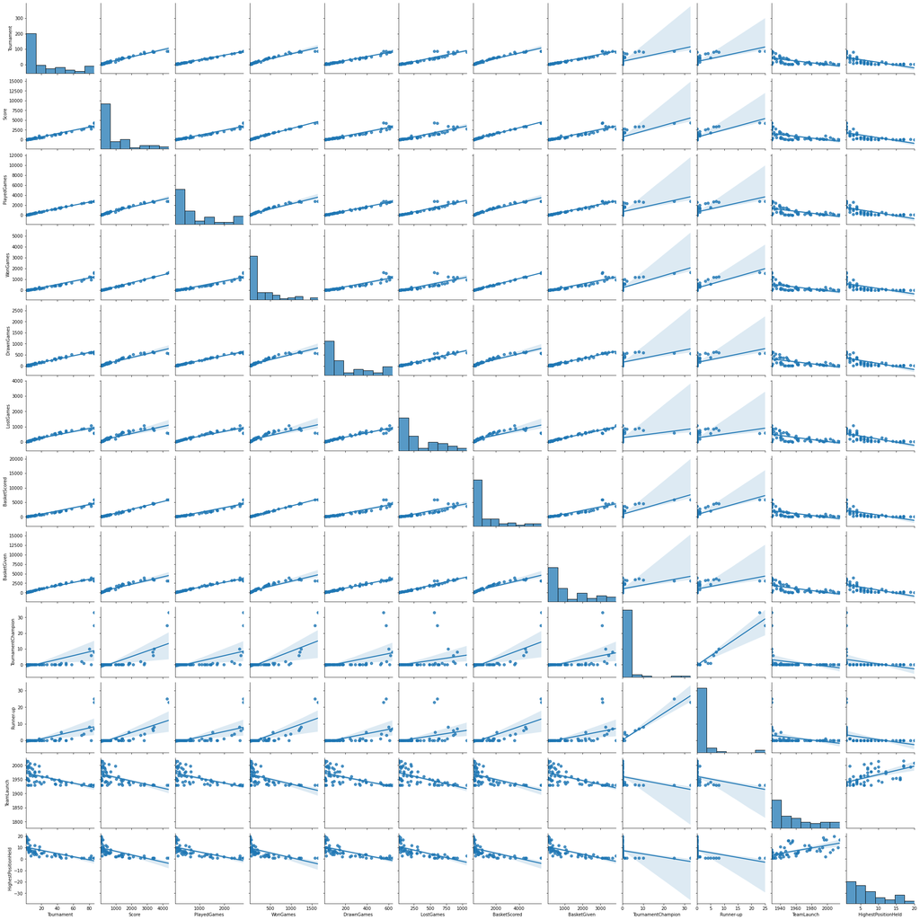

```python
sns.pairplot(bBall, kind='reg')
plt.show()
```

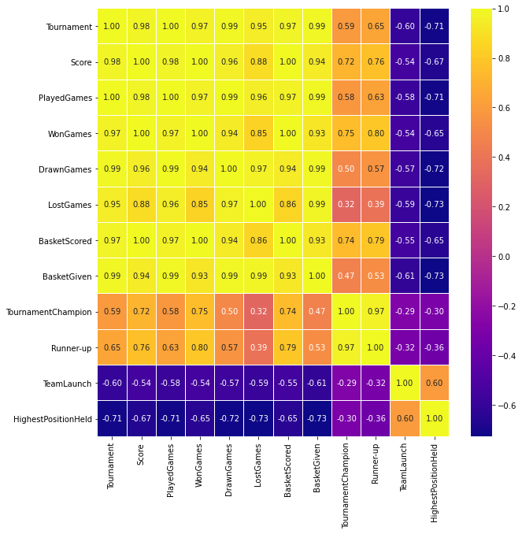

```python
fig,ax = plt.subplots(figsize=(10, 10))
sns.heatmap(bBall.corr(), annot=True, ax=ax, linewidths=0.05,fmt='.2f',cmap='plasma',)
plt.show()
```

```python
bBall.skew()
```

```
Tournament             1.197176
Score                  1.574104
PlayedGames            1.123454
WonGames               1.786067
DrawnGames             0.984899
LostGames              0.880596
BasketScored           1.758058
BasketGiven            0.958164
TournamentChampion     4.734845
Runner-up              4.321794
TeamLaunch             0.682570
HighestPositionHeld    0.832164
dtype: float64
```

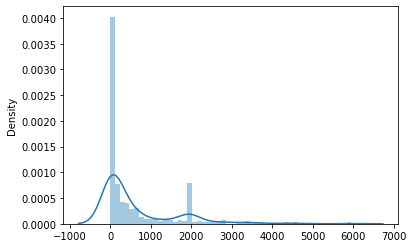

```python
bBallAna = bBall[convertTypes].copy(deep=True)
sns.distplot(bBallAna,bins=50)
plt.show()
```

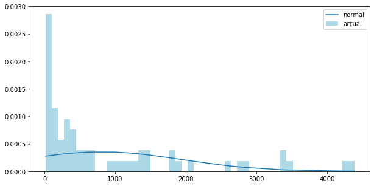

```
916.45 395.5
```

```python
plt.figure(figsize=(10,5))
scoreArr=np.asarray(bBallAna['Score']);

fit=stats.norm.pdf(scoreArr,np.mean(h),np.std(scoreArr))
plt.plot(scoreArr,fit,label='normal')
plt.hist(scoreArr,bins=50,density = True,color='LightBlue', label='actual')
plt.legend()
plt.show()
# As we can see our data is right Skewed or positive skewed
print(bBallAna['Score'].mean(), bBallAna['Score'].median())
#as we can see mean and median are so far so we can also say it's right skewed
```

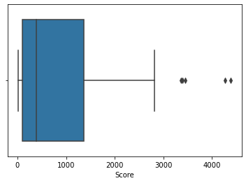

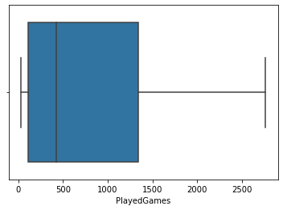

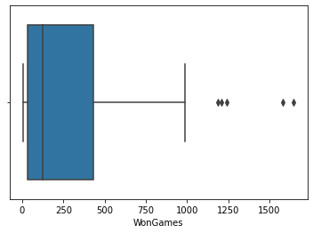

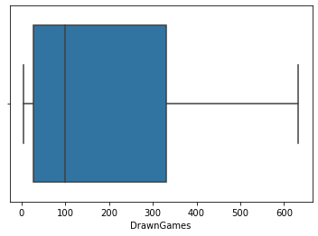

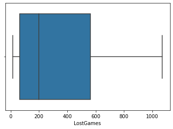

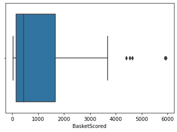

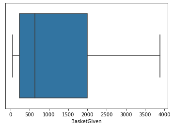

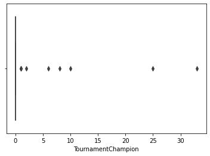

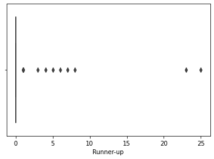

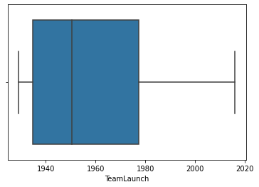

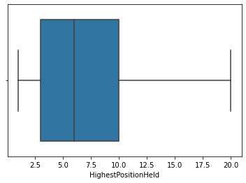

```python
#plot data in boxplot so we can see outliers

for col in bBallAna:
    sns.boxplot(x=bBallAna[col])
    plt.show()
```

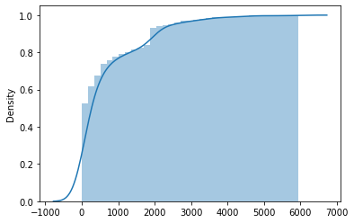

```python
sns.distplot(bBall[convertTypes], hist_kws=dict(cumulative=True), kde_kws=dict(cumulative=True))
```

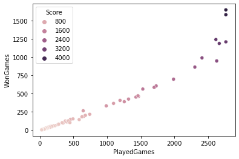

```python
sns.scatterplot(bBall['PlayedGames'],bBall['WonGames'],hue=bBall['Score']);
```

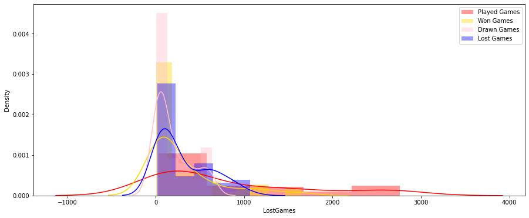

```python
plt.figure(figsize=(15,6))
sns.distplot(bBall['PlayedGames'], color = 'Red', label = 'Played Games')
sns.distplot(bBall['WonGames'], color = 'Gold', label = 'Won Games')
sns.distplot(bBall['DrawnGames'], color = 'Pink', label = 'Drawn Games')
sns.distplot(bBall['LostGames'], color = 'Blue', label = 'Lost Games')
plt.legend()
plt.show()
```

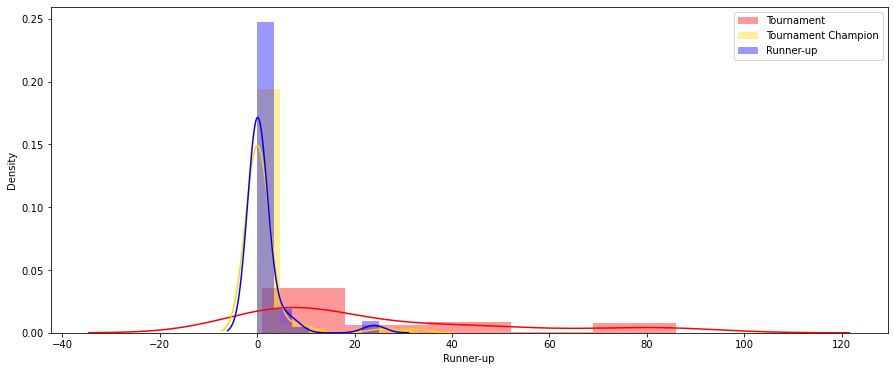

```python
plt.figure(figsize=(15,6))
sns.distplot(bBall['Tournament'], color = 'Red', label = 'Tournament')
sns.distplot(bBall['TournamentChampion'], color = 'Gold', label = 'Tournament Champion')
sns.distplot(bBall['Runner-up'], color = 'blue', label = 'Runner-up')
plt.legend()
plt.show()
```

```python
bBall['Won Percentage'] = round((bBall['WonGames']/bBall['PlayedGames'])*100,2)
bBall['Drawn Percentage'] = round((bBall['DrawnGames']/bBall['PlayedGames'])*100,2)
bBall['Lost Percentage'] = round((bBall['LostGames']/bBall['PlayedGames'])*100,2)
bBall.head()
```

|  | Team | Tournament | Score | PlayedGames | WonGames | DrawnGames | LostGames | BasketScored | BasketGiven | TournamentChampion | Runner-up | TeamLaunch | HighestPositionHeld | Won Percentage | Drawn Percentage | Lost Percentage |
| --- | --- | --- | --- | --- | --- | --- | --- | --- | --- | --- | --- | --- | --- | --- | --- | --- |
| 0 | Team 1 | 86 | 4385 | 2762 | 1647 | 552 | 563 | 5947 | 3140 | 33 | 23 | 1929 | 1 | 59.63 | 19.99 | 20.38 |
| 1 | Team 2 | 86 | 4262 | 2762 | 1581 | 573 | 608 | 5900 | 3114 | 25 | 25 | 1929 | 1 | 57.24 | 20.75 | 22.01 |
| 2 | Team 3 | 80 | 3442 | 2614 | 1241 | 598 | 775 | 4534 | 3309 | 10 | 8 | 1929 | 1 | 47.48 | 22.88 | 29.65 |
| 3 | Team 4 | 82 | 3386 | 2664 | 1187 | 616 | 861 | 4398 | 3469 | 6 | 6 | 1931 | 1 | 44.56 | 23.12 | 32.32 |
| 4 | Team 5 | 86 | 3368 | 2762 | 1209 | 633 | 920 | 4631 | 3700 | 8 | 7 | 1929 | 1 | 43.77 | 22.92 | 33.31 |

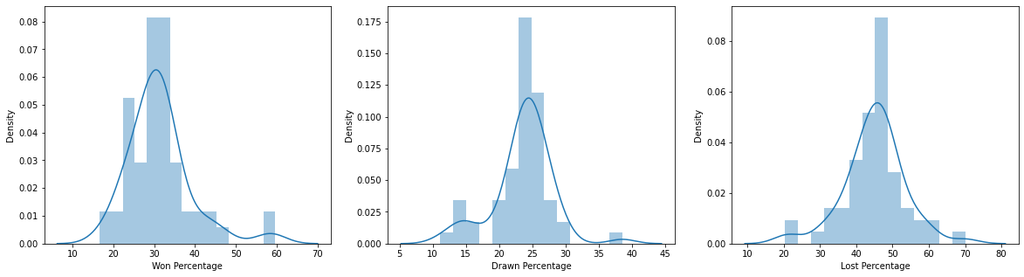

```python
fig, ax = plt.subplots(1, 3)
fig.set_figheight(5)
fig.set_figwidth(20)

sns.distplot(bBall['Won Percentage'],ax=ax[0])
sns.distplot(bBall['Drawn Percentage'],ax=ax[1])
sns.distplot(bBall['Lost Percentage'],ax=ax[2])
plt.show()
```

```python
wonTeam = bBall.where(bBall['Won Percentage'] == bBall['Won Percentage'].max())
wonTeam.dropna(inplace=True)
print ("Highest time won teams: ", wonTeam['Team'].values ," with ", wonTeam['Won Percentage'].values ,"percentages of winning rate, respectively")
```

```
Highest time won teams:  ['Team 1']  with  [59.63] percentages of winning rate, respectively
```

### 3 Please include any improvements or suggestions to the association management on quality, quantity, variety, velocity, veracity etc. on the data points collected by the association to perform a better data analysis in future. At-least 1 suggestion for each point.

**Quality:** Incomplete infomation of data was present in data set. Data is also not in proper format and Team 61 data is absent like score and played games are absent.

**Quantity:** Adding players information will increase our volumn of data by allowing us to pre-select which team will have the better winning probability.

**Variety:** To analyze a team other then the given data, more details can be added . For instance, if the team is highest positioned column, then the target value should be added.

**Veracity:** There are many outliers in our data, also missing values are there it may create ambiguity in result

If we want to predict which team will win then it'll be based upon players not upon team. So player information is needed to prediction.

We can add some more attributes so It can help to identify data precisely.

There are some teams which are playing since 1929. Amoung them some teams played very less games so it's difficult to say that those teams are still playing.

For analyse chances of winning next game we'll have to analyse players perfomance. and based on perfomance we can say this team may win.

# PART C (15 Marks)

```python
# 1
StartupC = pd.read_csv('CompanyX_EU.csv')
StartupC.head()
```

|  | Startup | Product | Funding | Event | Result | OperatingState |
| --- | --- | --- | --- | --- | --- | --- |
| 0 | 2600Hz | 2600hz.com | NaN | Disrupt SF 2013 | Contestant | Operating |
| 1 | 3DLT | 3dlt.com | $630K | Disrupt NYC 2013 | Contestant | Closed |
| 2 | 3DPrinterOS | 3dprinteros.com | NaN | Disrupt SF 2016 | Contestant | Operating |
| 3 | 3Dprintler | 3dprintler.com | $1M | Disrupt NY 2016 | Audience choice | Operating |
| 4 | 42 Technologies | 42technologies.com | NaN | Disrupt NYC 2013 | Contestant | Operating |

```python
# 2
StartupC.info()
StartupC.isna().sum()
```

```
<class 'pandas.core.frame.DataFrame'>
RangeIndex: 662 entries, 0 to 661
Data columns (total 6 columns):
 #   Column          Non-Null Count  Dtype
---  ------          --------------  -----
 0   Startup         662 non-null    object
 1   Product         656 non-null    object
 2   Funding         448 non-null    object
 3   Event           662 non-null    object
 4   Result          662 non-null    object
 5   OperatingState  662 non-null    object
dtypes: object(6)
memory usage: 31.2+ KB
```

```
Startup             0
Product             6
Funding           214
Event               0
Result              0
OperatingState      0
dtype: int64
```

```python
#3. A
StartupC = StartupC.dropna()
StartupC.isna().sum()
```

```
Startup           0
Product           0
Funding           0
Event             0
Result            0
OperatingState    0
dtype: int64
```

```python
StartupC.loc[:,'Funds_in_million'] = StartupC['Funding'].apply(lambda x: float(x[1:-1])/1000 if x[-1] == 'K' else (float(x[1:-1])*1000 if x[-1] == 'B' else float(x[1:-1])))
```

```
count     446.000000
mean       17.241489
std        90.483710
min         0.005000
25%         0.745250
50%         2.200000
75%         9.475000
max      1700.000000
Name: Funds_in_million, dtype: float64
```

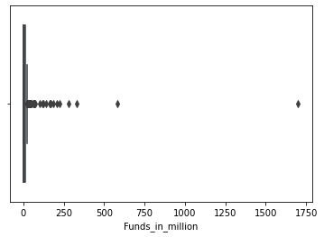

```python
# 3 C
print(StartupC.Funds_in_million.describe())
sns.boxplot(StartupC['Funds_in_million'])
```

```python
# 3 E
StartupC.OperatingState.value_counts()
```

```
Operating    319
Acquired      66
Closed        57
Ipo            4
Name: OperatingState, dtype: int64
```

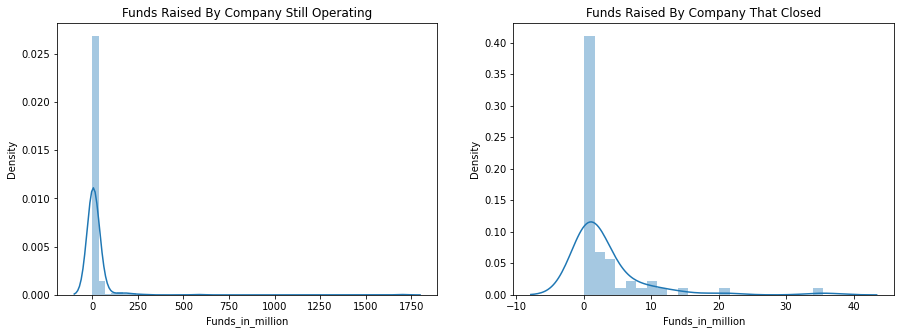

```python
# 4 A
fig,ax = plt.subplots(1,2)

fig.set_figheight(5)
fig.set_figwidth(15)

sns.distplot(StartupC.loc[StartupC.OperatingState == "Operating", "Funds_in_million"],ax=ax[0])
sns.distplot(StartupC.loc[StartupC.OperatingState == "Closed", "Funds_in_million"],ax=ax[1])

ax[0].set_title("Funds Raised By Company Still Operating");
ax[1].set_title("Funds Raised By Company That Closed");

plt.show()
```

### 4 B

#### Null Hypothesis H0:

```
 Mean of Operating & Closed State is same
```

#### Alternative Hypothesis Ha:

```
Mean of Operating & Closed State is not same and significant difference is available
```

```python
# 4 C
from statsmodels.stats.weightstats import ztest

s1 = StartupC.loc[StartupC.OperatingState == "Operating", "Funds_in_million"]
s2 = StartupC.loc[StartupC.OperatingState == "Closed", "Funds_in_million"]

# significant level is 5 %
alpha = 0.05

test_stat,p_value = ztest(s1,s2)

if(p_value<alpha):
    print('P Value, ',p_value ,' < ', alpha ,' There is significant difference so we can reject Null Hypothesis H0')
else:
    print('P Value, ',p_value ,' < ', alpha ,' There is not significant difference so we failed to reject Null Hypothesis H0')
```

```
P Value,  0.25499838490589677  <  0.05  There is not significant difference so we failed to reject Null Hypothesis H0
```

```python
# 4 E
df = StartupC.copy(deep=True)
df.head()
```

|  | Startup | Product | Funding | Event | Result | OperatingState | Funds_in_million |
| --- | --- | --- | --- | --- | --- | --- | --- |
| 1 | 3DLT | 3dlt.com | $630K | Disrupt NYC 2013 | Contestant | Closed | 0.63 |
| 3 | 3Dprintler | 3dprintler.com | $1M | Disrupt NY 2016 | Audience choice | Operating | 1.00 |
| 5 | 5to1 | 5to1.com | $19.3M | TC50 2009 | Contestant | Acquired | 19.30 |
| 6 | 8 Securities | 8securities.com | $29M | Disrupt Beijing 2011 | Finalist | Operating | 29.00 |
| 10 | AdhereTech | adheretech.com | $1.8M | Hardware Battlefield 2014 | Contestant | Operating | 1.80 |

```python
df.Result.value_counts()
```

```
Contestant         312
Finalist            65
Winner              25
Audience choice     25
Runner up           19
Name: Result, dtype: int64
```

```python
# 4 F
winner = df.Result.value_counts()[1:].sum()
contestant = df.Result.value_counts()["Contestant"]

contestant_operat = df.OperatingState[df.Result == "Contestant"].value_counts().loc['Operating']
winner_operat = df.OperatingState[df.Result != "Contestant"].value_counts().loc['Operating']

print("winners that are still operating:",winner_operat/winner,"%")
print("Contestants that are still operating:",contestant_operat/contestant,"%")
```

```
winners that are still operating: 0.7835820895522388 %
Contestants that are still operating: 0.6858974358974359 %
```

### 4 G

**Null Hypothesis H0:** The propotion of companies that are operating is same in both categories- Winner & Contestant

**Alternative Hypothesis Ha:** The propotion of companies that are operating is significantly different from each other.

```python
# 4 H
from statsmodels.stats.proportion import proportions_ztest
alpha = 0.05
test_stat , p_val = proportions_ztest([contestant_operat,winner_operat],[contestant,winner])
if(p_val < alpha):
    print('P Value, ',round(p_val,3) ,' < ', alpha ,' There is significant difference so we can reject the Null Hypothesis H0')
else:
    print('P Value, ',round(p_val,3) ,' < ', alpha ,' There is not significant difference so we failed to the reject Null Hypothesis H0')
```

```
P Value,  0.036  <  0.05  There is significant difference so we can reject the Null Hypothesis H0
```

```python
# 4 I
distEvent = df[df.Event.apply(lambda x: 'Disrupt' in x[0:7] and x[-4:] == '2013')].Event
distEvent
```

```
1      Disrupt NYC 2013
42      Disrupt EU 2013
53      Disrupt SF 2013
63      Disrupt SF 2013
72      Disrupt SF 2013
76      Disrupt SF 2013
126     Disrupt SF 2013
149    Disrupt NYC 2013
150    Disrupt NYC 2013
158    Disrupt NYC 2013
159     Disrupt SF 2013
160     Disrupt SF 2013
166    Disrupt NYC 2013
182     Disrupt SF 2013
192    Disrupt NYC 2013
```

[output cut: 39 more lines]